# House Prices

Cason Wight

5/2/2020

Since getting married, my wife and I have always talked about what we would look for in a home. Whenever we are traveling, we open Zillow to get estimated prices for the houses that we see. I am honestly surprised by which houses end up more expensive. This post will be a simple exploratory data analysis and initial modeling of house prices. This type of raw, initial look is inspired by the weekly *tidy tuesday* screencasts from [Julia Silge](https://www.youtube.com/channel/UCTTBgWyJl2HrrhQOOc710kA) and [David Robinson](https://www.youtube.com/user/safe4democracy) from `Rstudio`. For anyone interested indeveloping their general workflow and abilities in the `tidyverse`, I would highly recommend tuning in to these weekly posts.

The data were obtained from a [kaggle competition](https://www.kaggle.com/c/house-prices-advanced-regression-techniques/data). The *tidy tuesday* screencasts are done in `R` using the `tidyverse`. I have been working on my `python` skills, so I have repeated my analysis in python’s `pandas` as well.

##### Loading the Necessary Packages

###### R

I will use the tidyverse for data manipulation (ggplot2 for visualizations).

```r
library(tidyverse)
library(lubridate)
library(scales)
```

###### Python

```python
import pandas as pd
import numpy as np
import random
#from plotnine import ggplot, aes, geom_point, geom_line
```

##### Reading in the Data

###### R

```r
train.r <- read_csv("train.csv")[,-1]
head(train.r)
```

```
## # A tibble: 6 x 80
##   MSSubClass MSZoning LotFrontage LotArea Street Alley LotShape LandContour
##        <dbl> <chr>          <dbl>   <dbl> <chr>  <chr> <chr>    <chr>
## 1         60 RL                65    8450 Pave   <NA>  Reg      Lvl
## 2         20 RL                80    9600 Pave   <NA>  Reg      Lvl
## 3         60 RL                68   11250 Pave   <NA>  IR1      Lvl
## 4         70 RL                60    9550 Pave   <NA>  IR1      Lvl
## 5         60 RL                84   14260 Pave   <NA>  IR1      Lvl
## 6         50 RL                85   14115 Pave   <NA>  IR1      Lvl
## # ... with 72 more variables: Utilities <chr>, LotConfig <chr>,
## #   LandSlope <chr>, Neighborhood <chr>, Condition1 <chr>, Condition2 <chr>,
## #   BldgType <chr>, HouseStyle <chr>, OverallQual <dbl>, OverallCond <dbl>,
## #   YearBuilt <dbl>, YearRemodAdd <dbl>, RoofStyle <chr>, RoofMatl <chr>,
## #   Exterior1st <chr>, Exterior2nd <chr>, MasVnrType <chr>, MasVnrArea <dbl>,
## #   ExterQual <chr>, ExterCond <chr>, Foundation <chr>, BsmtQual <chr>,
## #   BsmtCond <chr>, BsmtExposure <chr>, BsmtFinType1 <chr>, BsmtFinSF1 <dbl>,
## #   BsmtFinType2 <chr>, BsmtFinSF2 <dbl>, BsmtUnfSF <dbl>, TotalBsmtSF <dbl>,
## #   Heating <chr>, HeatingQC <chr>, CentralAir <chr>, Electrical <chr>,
## #   `1stFlrSF` <dbl>, `2ndFlrSF` <dbl>, LowQualFinSF <dbl>, GrLivArea <dbl>,
## #   BsmtFullBath <dbl>, BsmtHalfBath <dbl>, FullBath <dbl>, HalfBath <dbl>,
## #   BedroomAbvGr <dbl>, KitchenAbvGr <dbl>, KitchenQual <chr>,
## #   TotRmsAbvGrd <dbl>, Functional <chr>, Fireplaces <dbl>, FireplaceQu <chr>,
## #   GarageType <chr>, GarageYrBlt <dbl>, GarageFinish <chr>, GarageCars <dbl>,
## #   GarageArea <dbl>, GarageQual <chr>, GarageCond <chr>, PavedDrive <chr>,
## #   WoodDeckSF <dbl>, OpenPorchSF <dbl>, EnclosedPorch <dbl>,
## #   `3SsnPorch` <dbl>, ScreenPorch <dbl>, PoolArea <dbl>, PoolQC <chr>,
## #   Fence <chr>, MiscFeature <chr>, MiscVal <dbl>, MoSold <dbl>, YrSold <dbl>,
## #   SaleType <chr>, SaleCondition <chr>, SalePrice <dbl>
```

###### Python

```python
train_py = pd.read_csv("train.csv").iloc[:,1:]
train_py.head()
```

```
##    MSSubClass MSZoning  LotFrontage  ...  SaleType SaleCondition SalePrice
## 0          60       RL         65.0  ...        WD        Normal    208500
## 1          20       RL         80.0  ...        WD        Normal    181500
## 2          60       RL         68.0  ...        WD        Normal    223500
## 3          70       RL         60.0  ...        WD       Abnorml    140000
## 4          60       RL         84.0  ...        WD        Normal    250000
##
## [5 rows x 80 columns]
```

##### Are Prices Increasing over Time?

###### R

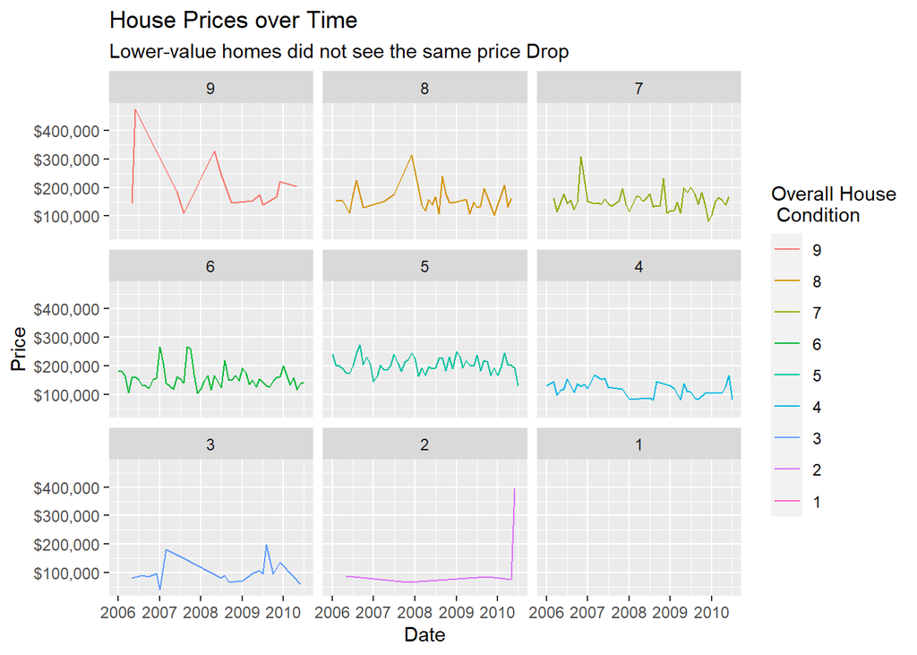

```r
train.r$dateSold <- as.POSIXct(paste(train.r$YrSold,train.r$MoSold, "01", sep = "-"),format='%Y-%m-%d')

train.r %>% group_by(dateSold, OverallCond) %>%
  summarize(price = mean(SalePrice)) %>%
  mutate(OverallCond = factor(OverallCond, levels = 9:1)) %>%
  ggplot(aes(dateSold, price, color = OverallCond)) +
  geom_line() +
  facet_wrap(~ OverallCond) +
  labs(title = "House Prices over Time", x = "Date", color = "Overall House\n Condition", subtitle = "Lower-value homes did not see the same price Drop") +
  scale_y_continuous(name="Price", labels = scales::dollar)
```

###### Python

```python
train_py['dateSold'] = pd.to_datetime(train_py['YrSold'].astype(str) + train_py['MoSold'].astype(str), format='%Y%m')
grouped_prices_py = (train_py
  .groupby(['dateSold', 'OverallCond'])
  .mean()['SalePrice']
  .unstack()
  .reset_index()
  .melt("dateSold")
  .dropna(axis = 0))


#print(grouped_prices_py.head())

#(ggplot(grouped_prices_py, aes(x = "dateSold", y = "value"))
#  + geom_point())
```

```python
fig, ax = plt.subplots( nrows=1, ncols=1 )
ax.plot(grouped_prices_py.dateSold, grouped_prices_py.value)
fig.savefig("price_by_time.png")
```

[output not shown]